# EDS 223: Discussion Week 6 - Vector Raster Interactions

Name

2023-08-28

## introduction

The following exercises are modified from [Chapter 6 of Geocomputation with R by Rovin Lovelace](https://r.geocompx.org/raster-vector).

## prerequisites

```r
library(sf)
library(terra)
library(spData)
library(spDataLarge)
library(tidyverse)
```

```r
zion_points = read_sf(system.file("vector/zion_points.gpkg", package = "spDataLarge"))
srtm = rast(system.file("raster/srtm.tif", package = "spDataLarge"))

ch = st_combine(zion_points) |>
  st_convex_hull() |>
  st_as_sf()

grain = rast(system.file("raster/grain.tif", package = "spData"))
```

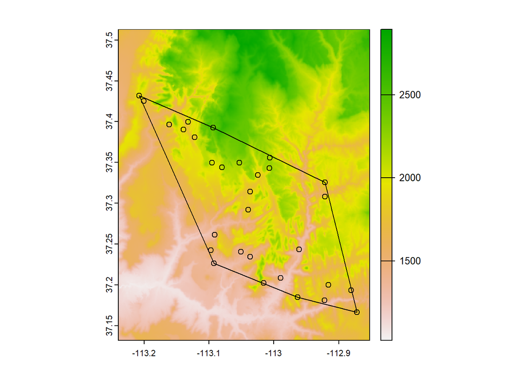

```r
plot(srtm)
plot(st_geometry(zion_points), add = TRUE)
plot(ch, add = TRUE)
```

## Exercises

1. Crop the srtm raster using (1) the zion_points dataset and (2) the ch dataset. Are there any differences in the output maps? Next, mask srtm using these two datasets. Can you see any difference now?

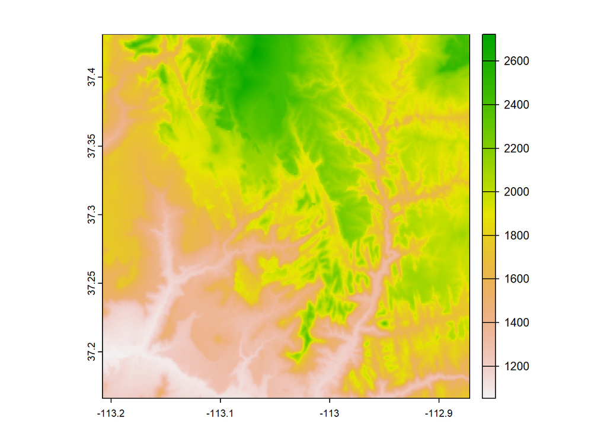

```r
srtm_crop1 = crop(srtm, zion_points)
srtm_crop2 = crop(srtm, ch)
plot(srtm_crop1)
plot(srtm_crop2)
```

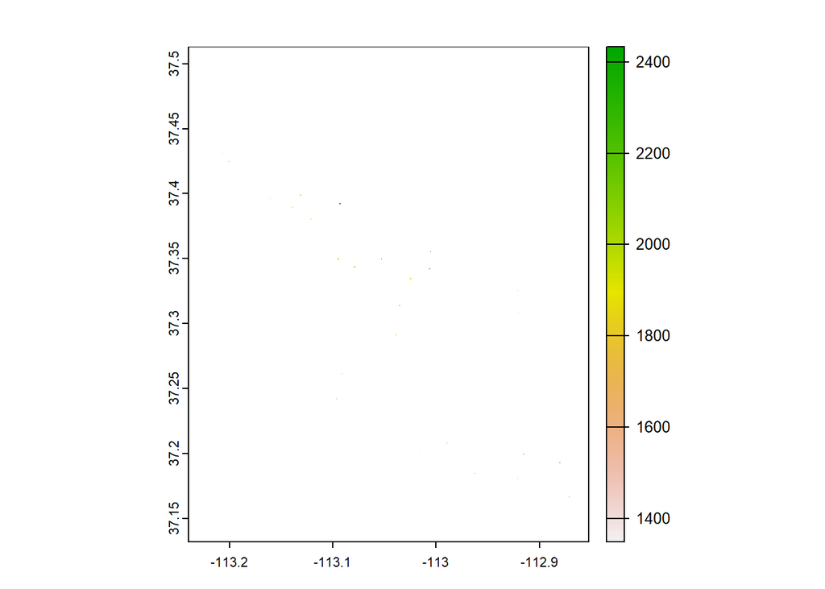

```r
srtm_mask1 = mask(srtm, zion_points)
srtm_mask2 = mask(srtm, ch)
plot(srtm_mask1)
```

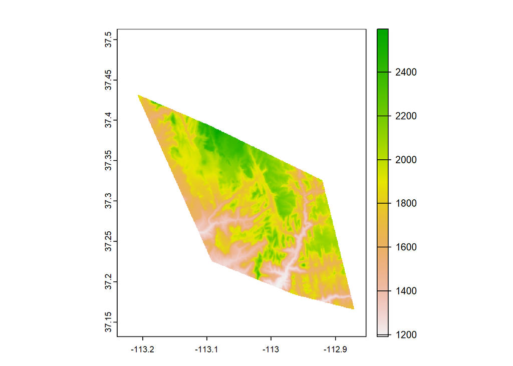

```r
plot(srtm_mask2)
```

2. Subset points higher than 3100 meters in New Zealand (the nz_height object) and create a template raster with a resolution of 3 km for the extent of the new point dataset. Using these two new objects:

```r
nz_height3100 = nz_height %>%
  filter(elevation > 3100)

nz_template = rast(ext(nz_height3100), resolution = 3000, crs = crs(nz_height3100))
```

2a. Count numbers of the highest points in each grid cell.

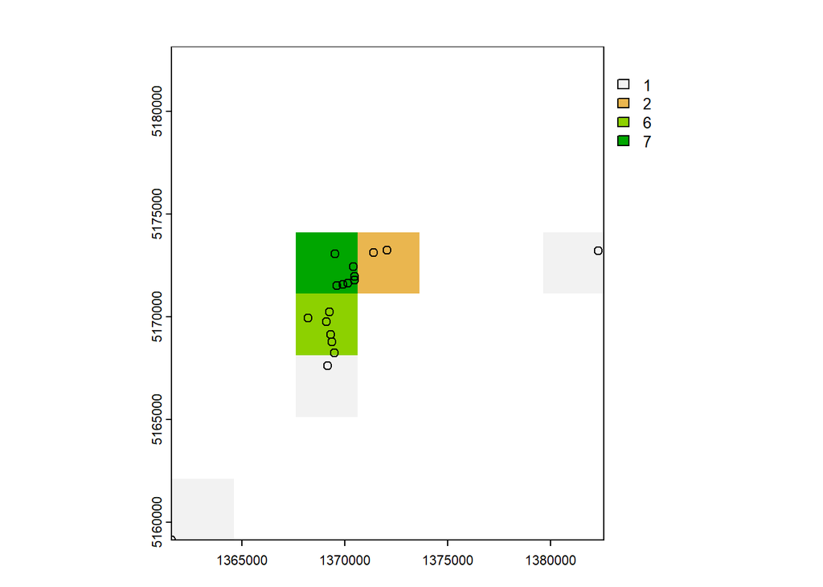

```r
nz_raster = rasterize(nz_height3100, nz_template,
                       field = "elevation", fun = "length")
plot(nz_raster)
plot(st_geometry(nz_height3100), add = TRUE)
```

2b. Find the maximum elevation in each grid cell.

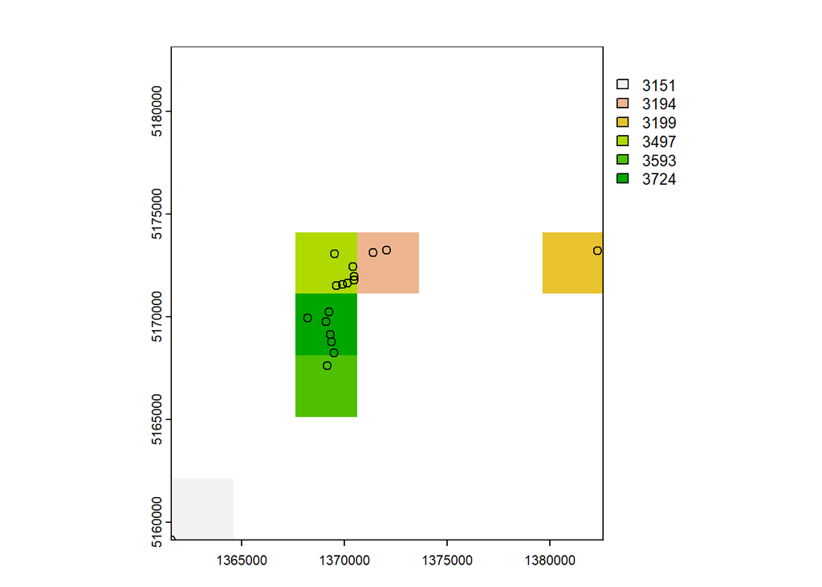

```r
nz_raster2 = rasterize(nz_height3100, nz_template,
                       field = "elevation", fun = max)
plot(nz_raster2)
plot(st_geometry(nz_height3100), add = TRUE)
```

3. Aggregate the raster counting high points in New Zealand (created in the previous exercise), reduce its geographic resolution by half (so cells are 6 by 6 km) and plot the result. Resample the lower resolution raster back to the original resolution of 3 km.

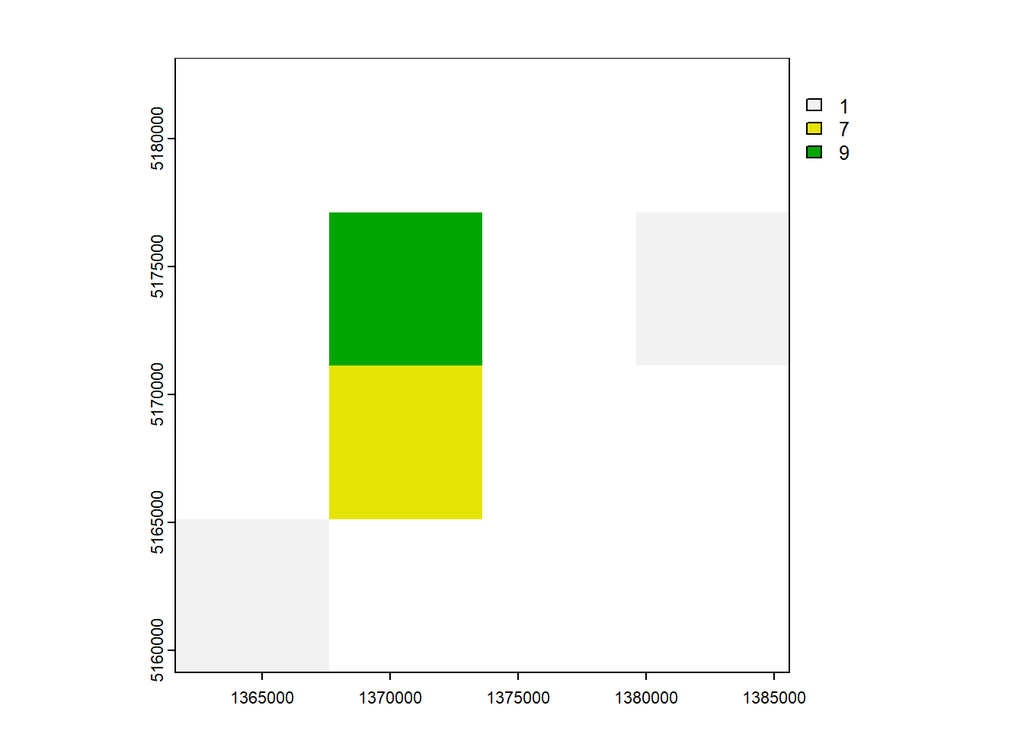

```r
nz_raster_low = raster::aggregate(nz_raster, fact = 2, fun = sum, na.rm = TRUE)

nz_resample = resample(nz_raster_low, nz_raster)
plot(nz_raster_low)
```

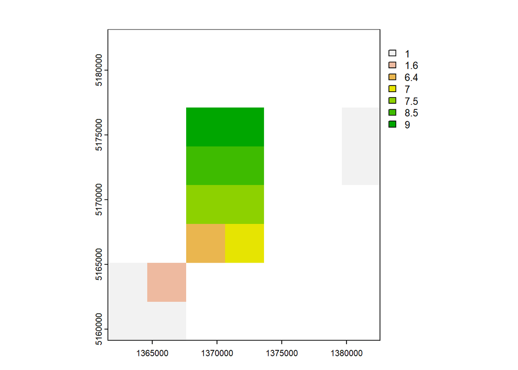

```r
plot(nz_resample) # the results are spread over a greater area and there are border issues
```

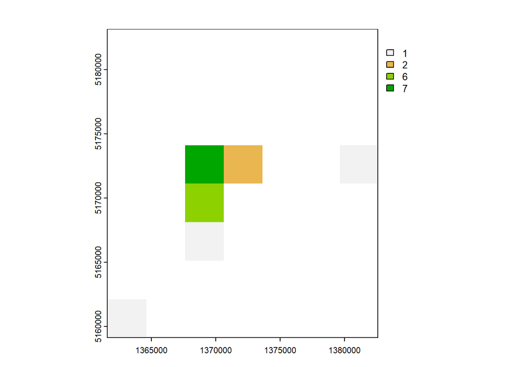

```r
plot(nz_raster)
```

4. Polygonize the grain dataset and filter all squares representing clay.

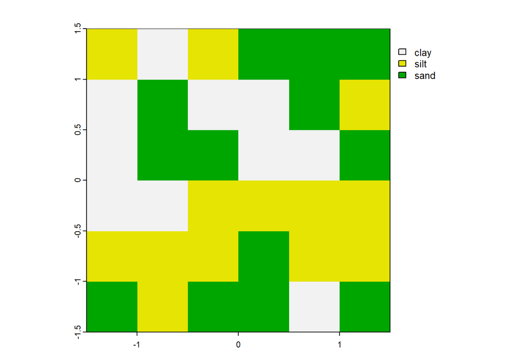

```r
grain_poly = as.polygons(grain) %>%
  st_as_sf()

plot(grain)
```

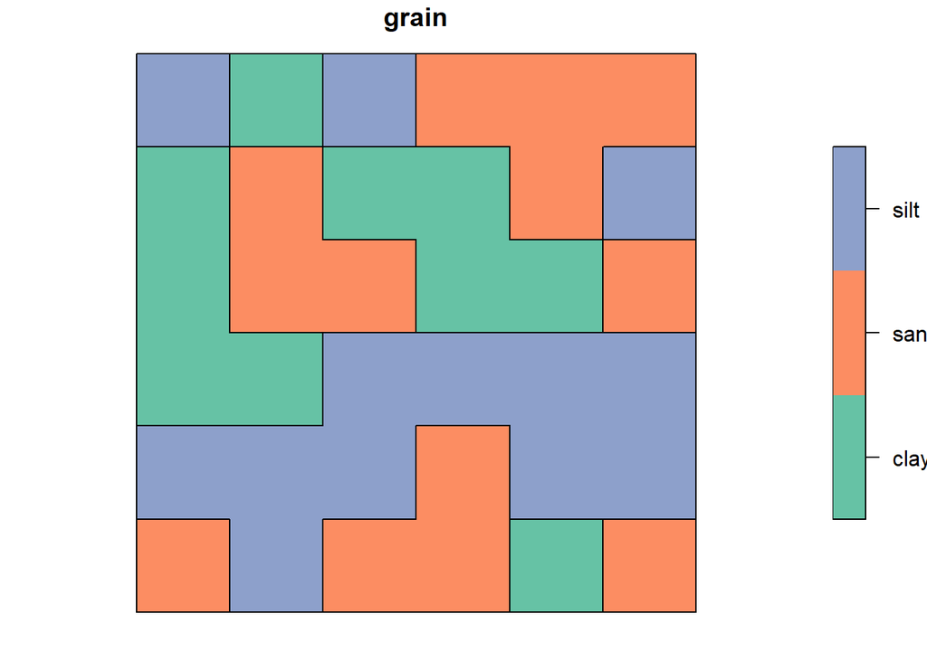

```r
plot(grain_poly)
```

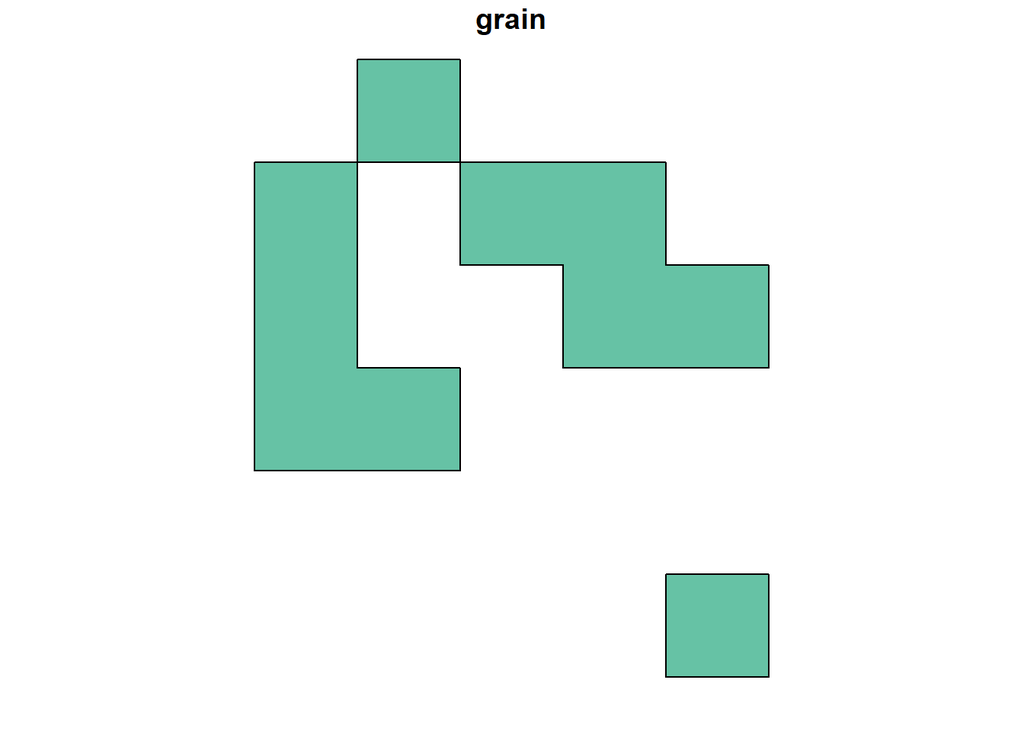

```r
clay = grain_poly %>%
  filter(grain == "clay")
plot(clay)
```